# Part II - Walmart Retail Dataset

## by Arikan Udoka

## Investigation Overview

My goal is to find out which products sell the most; region, state and product categories with the most orders. and how these categories relate with each other.

## Dataset Overview

There are 8399 orders from 795 customers across 48 states and 4 regions, 63 rows were dropped due to null values and 13 columns were dropped as they were not necessary to the analysis.

## Product Category by Order Quantity

For this presentation I'll focus more on Product Category, Region and Order Count/Order Quantity. I'll start by introducing the Product Category and Order Count/Order Quantity with a bar chart.

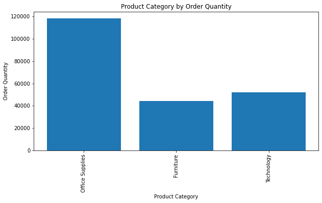

Next we see a pie chart that isn't a good chart to visualize the data we want to see.

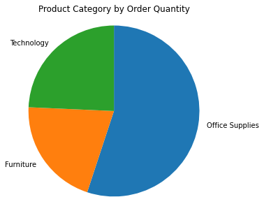

## Order Quantity by Region

Then we'll move on to Region and Order Count/Order Quantity using another bar chart as we are still trying to see which has the highest.

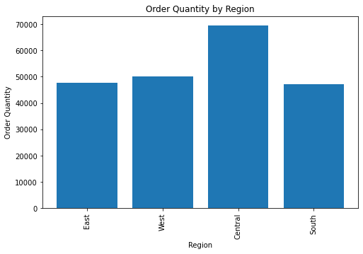

## Product Category Order Count by Region

Next we'll see the Product Category and Order Count/Order Quantity by region to see how these relate and if there are any changes to what we saw previously.

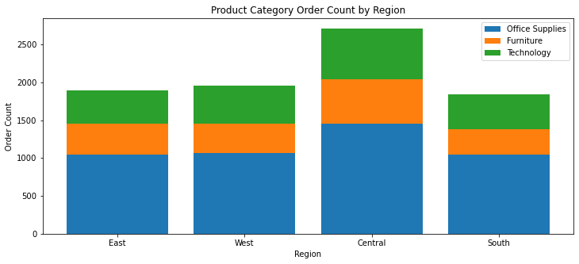

## Sales by Order Quantity and Region

Finally, I close out with the scatter plot showing how there's a stark difference when another variable not previously used changes how we view the data.

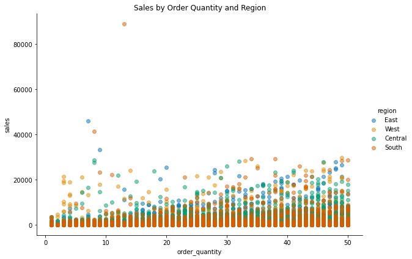